# Financial Industry: Credit Scoring

## Credit Risk Analysis

### Background

In the financial industry, credit scoring is the key to determining whether someone is eligible for a loan. However, the traditional process is often slow and cumbersome for potential borrowers. To overcome this, banks and financial institutions are starting to adopt machine learning technology. By analyzing borrower profile data and payment patterns, machine learning models can quickly and accurately predict credit risk. This allows banks to offer loans faster, while still reducing the risk of default. Thus, the use of machine learning in credit scoring not only improves process efficiency, but also helps optimize credit decisions and reduce operational costs.

### Modelling Analysis

#### Cleaning data

```r
credit <- read_csv("data_input/credit_record.csv")
application <- read_csv("data_input/application_record.csv")
```

Data Description:

**Credit**

- ID : Client number
- MONTHS_BALANCE : Record month The month of the extracted data is the starting point, backwards, 0 is the current month, -1 is the previous month, and so on
- STATUS : Status
  - 0: 1-29 days past due
  - 1: 30-59 days past due
  - 2: 60-89 days overdue
  - 3: 90-119 days overdue
  - 4: 120-149 days overdue
  - 5: Overdue or bad debts, write-offs for more than 150 days
  - C: paid off that month
  - X: No loan for the month

**Application**

- ID : Client number
- CODE_GENDER : Gender
- FLAG_OWN_CAR : Is there a car
- FLAG_OWN_REALTY ; Is there a property
- CNT_CHILDREN : Number of children
- AMT_INCOME_TOTAL : Annual income
- NAME_INCOME_TYPE : Income category
- NAME_EDUCATION_TYPE : Education level
- NAME_FAMILY_STATUS : Marital status
- NAME_HOUSING_TYPE : Way of living
- DAYS_BIRTH : Birthday Count backwards from current day (0), -1 means yesterday
- DAYS_EMPLOYED : Start date of employment Count backwards from current day(0). If positive, it means - - the person currently unemployed.
- FLAG_MOBIL : Is there a mobile phone
- FLAG_WORK_PHONE : Is there a work phone
- FLAG_PHONE : Is there a phone
- FLAG_EMAIL : Is there an email
- OCCUPATION_TYPE : Occupation
- CNT_FAM_MEMBERS :Family size

**Check missing values**

There are no missing values in the credit data

```r
colSums(is.na(credit))
```

```
#>             ID MONTHS_BALANCE         STATUS
#>              0              0              0
```

```r
colSums(is.na(application))
```

```
#>                  ID         CODE_GENDER        FLAG_OWN_CAR     FLAG_OWN_REALTY
#>                   0                   0                   0                   0
#>        CNT_CHILDREN    AMT_INCOME_TOTAL    NAME_INCOME_TYPE NAME_EDUCATION_TYPE
#>                   0                   0                   0                   0
#>  NAME_FAMILY_STATUS   NAME_HOUSING_TYPE          DAYS_BIRTH       DAYS_EMPLOYED
#>                   0                   0                   0                   0
#>          FLAG_MOBIL     FLAG_WORK_PHONE          FLAG_PHONE          FLAG_EMAIL
#>                   0                   0                   0                   0
#>     OCCUPATION_TYPE     CNT_FAM_MEMBERS
#>              134203                   0
```

In the application data there is an `OCCUPATION_TYPE` variable that has a lot of missing data, we can discard the variable. Also, we will remove `DAYS_BIRTH` and `DAYS_EMPLOYED` variables that are not needed in the model.

```r
application <- application %>%
               select(-c(OCCUPATION_TYPE, DAYS_BIRTH, DAYS_EMPLOYED))
```

**Customizing data types**

The next step is to merge the credit and application data and adjust the categorical data types that are still read as characters.

```r
data_clean <- credit %>%
              left_join(application) %>%
              na.omit() %>%
              select(-ID) %>%
              filter(STATUS != "X") %>%
              mutate(STATUS = as.factor(ifelse(STATUS == "C", "good credit", "bad credit"))) %>%
              mutate_at(.vars = c("FLAG_MOBIL", "FLAG_WORK_PHONE",
                                  "FLAG_PHONE", "FLAG_EMAIL"), as.factor) %>%
              mutate_if(is.character, as.factor) %>%
              data.frame()
str(data_clean)
```

```
#> 'data.frame':    631765 obs. of  16 variables:
#>  $ MONTHS_BALANCE     : num  0 -1 -2 -3 -4 -5 -6 -7 -8 -9 ...
#>  $ STATUS             : Factor w/ 2 levels "bad credit","good credit": 2 2 2 2 2 2 2 2 2 2 ...
#>  $ CODE_GENDER        : Factor w/ 2 levels "F","M": 2 2 2 2 2 2 2 2 2 2 ...
#>  $ FLAG_OWN_CAR       : Factor w/ 2 levels "N","Y": 2 2 2 2 2 2 2 2 2 2 ...
#>  $ FLAG_OWN_REALTY    : Factor w/ 2 levels "N","Y": 2 2 2 2 2 2 2 2 2 2 ...
#>  $ CNT_CHILDREN       : num  0 0 0 0 0 0 0 0 0 0 ...
#>  $ AMT_INCOME_TOTAL   : num  427500 427500 427500 427500 427500 ...
#>  $ NAME_INCOME_TYPE   : Factor w/ 5 levels "Commercial associate",..: 5 5 5 5 5 5 5 5 5 5 ...
#>  $ NAME_EDUCATION_TYPE: Factor w/ 5 levels "Academic degree",..: 2 2 2 2 2 2 2 2 2 2 ...
#>  $ NAME_FAMILY_STATUS : Factor w/ 5 levels "Civil marriage",..: 1 1 1 1 1 1 1 1 1 1 ...
#>  $ NAME_HOUSING_TYPE  : Factor w/ 6 levels "Co-op apartment",..: 5 5 5 5 5 5 5 5 5 5 ...
#>  $ FLAG_MOBIL         : Factor w/ 1 level "1": 1 1 1 1 1 1 1 1 1 1 ...
#>  $ FLAG_WORK_PHONE    : Factor w/ 2 levels "0","1": 2 2 2 2 2 2 2 2 2 2 ...
#>  $ FLAG_PHONE         : Factor w/ 2 levels "0","1": 1 1 1 1 1 1 1 1 1 1 ...
#>  $ FLAG_EMAIL         : Factor w/ 2 levels "0","1": 1 1 1 1 1 1 1 1 1 1 ...
#>  $ CNT_FAM_MEMBERS    : num  2 2 2 2 2 2 2 2 2 2 ...
```

#### Exploratory Data Analysis (EDA)

In EDA data, we want to know how categorical and numerical data are distributed.

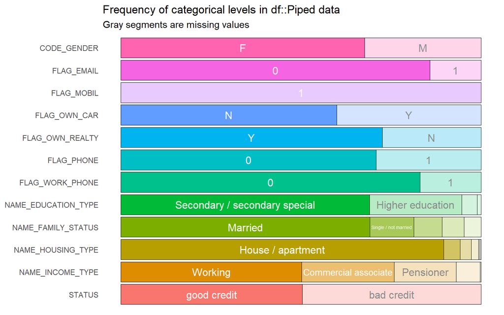

```r
data_clean %>% inspect_cat() %>% show_plot()
```

```r
data_clean <- data_clean %>%
              select(-c(FLAG_MOBIL,FLAG_EMAIL))
```

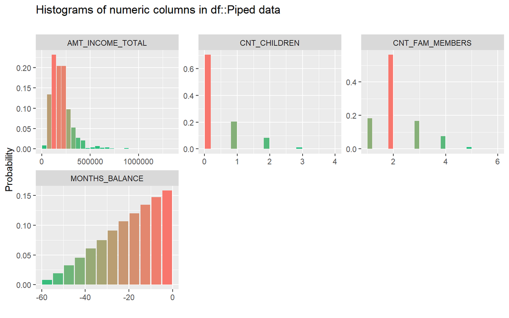

```r
data_clean %>% inspect_num() %>% show_plot()
```

#### Modelling Random Forest

Split train data and test data with a proportion of 80:20. The train data will be used for modeling, while the test data will be used for evaluation.

```r
set.seed(100)
index <- initial_split(data = data_clean, prop = 0.8, strata = "STATUS")
train <- training(index)
test <- testing(index)
```

Check the proportion of the target variable

```r
prop.table(table(train$STATUS))
```

```
#>
#>  bad credit good credit
#>   0.4960937   0.5039063
```

Shape of random forest model with 3 k-fold and 2 repetitions

```r
# set.seed(100)
#
# ctrl <- trainControl(method = "repeatedcv",
#                      number = 3,
#                      repeats = 2,
#                      allowParallel=FALSE)
#
# model_forest <- caret::train(STATUS ~.,
#                              data = train,
#                              method = "rf",
#                              trControl = ctrl)

#saveRDS(model_forest, "model_forest.RDS")

model_forest <- readRDS("model_forest.RDS")
```

```r
model_forest
```

```
#> Random Forest
#>
#> 80001 samples
#>    13 predictor
#>     2 classes: 'bad credit', 'good credit'
#>
#> No pre-processing
#> Resampling: Cross-Validated (3 fold, repeated 2 times)
#> Summary of sample sizes: 53335, 53334, 53333, 53334, 53334, 53334, ...
#> Resampling results across tuning parameters:
#>
#>   mtry  Accuracy   Kappa
#>    2    0.6432232  0.2846367
#>   14    0.7487656  0.4973803
#>   26    0.7114411  0.4230518
#>
#> Accuracy was used to select the optimal model using the largest value.
#> The final value used for the model was mtry = 14.
```

Next, predictions will be made for the test data and look for the confusion matrix value on the prediction results.

```r
pred_rf<- predict(model_forest, newdata = test, type = "prob") %>%
          mutate(result = as.factor(ifelse(`bad credit` > 0.45, "bad credit", "good credit")),
                 actual = ifelse(test$STATUS == 'good credit', 0, 1))
confmat_rf <- confusionMatrix(pred_rf$result,
                                 test$STATUS,
                                 mode = "prec_recall",
                                 positive = "bad credit")

eval_rf <- tidy(confmat_rf) %>%
  mutate(model = "Random Forest") %>%
  select(model, term, estimate) %>%
  filter(term %in% c("accuracy", "precision", "recall", "specificity"))

eval_rf
```

```
#> # A tibble: 4 × 3
#>   model         term        estimate
#>   <chr>         <chr>          <dbl>
#> 1 Random Forest accuracy       0.812
#> 2 Random Forest specificity    0.815
#> 3 Random Forest precision      0.811
#> 4 Random Forest recall         0.809
```

#### Modelling XGBoost

The next step is to implement the data using the XGBoost model, we need to prepare the data for the XGBoost model first.

```r
data_xgb <- data_clean %>%
            mutate(STATUS = ifelse(STATUS == "good credit", 0, 1)) %>%
            data.frame()
```

```r
set.seed(100)
index <- initial_split(data = data_xgb, prop = 0.8, strata = "STATUS")
train_xgb <- training(index)
test_xgb <- testing(index)
```

```r
label_train <- as.numeric(train_xgb$STATUS)
label_test <- as.numeric(test_xgb$STATUS)
```

```r
train_matrix <- data.matrix(train_xgb[,-2])
test_matrix <- data.matrix(test_xgb[,-2])
# convert data to Dmatrix
dtrain <- xgb.DMatrix(data = train_matrix, label = label_train)
dtest <- xgb.DMatrix(data = test_matrix, label = label_test)
```

```r
params <- list(booster = "gbtree",
               objective = "binary:logistic",
               eta=0.7,
               gamma=10,
               max_depth=10,
               min_child_weight=3,
               subsample=1,
               colsample_bytree=0.5)
```

```r
xgbcv <- xgb.cv( params = params,
                 data = dtrain,
                 nrounds = 1000,
                 showsd = T,
                 nfold = 10,
                 stratified = T,
                 print_every_n = 50,
                 early_stopping_rounds = 20,
                 maximize = F)
```

```
#> Multiple eval metrics are present. Will use test_logloss for early stopping.
#> Will train until test_logloss hasn't improved in 20 rounds.
#>
```

```r
print(xgbcv)
```

```
#> ##### xgb.cv 10-folds
#>     iter train_logloss_mean train_logloss_std test_logloss_mean
#>        1          0.6586617       0.007932747         0.6610580
#>        2          0.6261109       0.014786739         0.6318969
#>        3          0.6127767       0.018208261         0.6200069
#>        4          0.5954663       0.014391087         0.6041849
#>        5          0.5854660       0.014752739         0.5949785
#> ---
#>      996          0.4583978       0.001032491         0.4910331
#>      997          0.4583400       0.001056519         0.4910225
#>      998          0.4583307       0.001051172         0.4910193
#>      999          0.4583307       0.001051173         0.4910193
#>     1000          0.4583307       0.001051172         0.4910193
#>     test_logloss_std
#>          0.006557291
#>          0.013925367
#>          0.017604226
#>          0.014605105
#>          0.013268623
#> ---
#>          0.004250393
#>          0.004241653
#>          0.004244270
#>          0.004244261
#>          0.004244259
#> Best iteration:
#>  iter train_logloss_mean train_logloss_std test_logloss_mean test_logloss_std
#>  1000          0.4583307       0.001051172         0.4910193      0.004244259
```

```r
xgb1 <- xgb.train (params = params,
                   data = dtrain,
                   nrounds = xgbcv$best_iteration,
                   watchlist = list(val=dtest,train=dtrain),
                   print_every_n = 100,
                   early_stoping_rounds = 10,
                   maximize = F ,
                   eval_metric = "error",
                   verbosity = 0)
xgbpred_prob <-predict(object = xgb1, newdata = dtest)
xgbpred <- ifelse (xgbpred_prob > 0.45,1,0)
```

```r
confmat_xgb <- confusionMatrix(as.factor(xgbpred), as.factor(label_test), positive = "1")
confmat_xgb
```

```
#> Confusion Matrix and Statistics
#>
#>           Reference
#> Prediction    0    1
#>          0 7347 2255
#>          1 2732 7667
#>
#>                Accuracy : 0.7507
#>                  95% CI : (0.7446, 0.7566)
#>     No Information Rate : 0.5039
#>     P-Value [Acc > NIR] : < 0.00000000000000022
#>
#>                   Kappa : 0.5015
#>
#>  Mcnemar's Test P-Value : 0.00000000001579
#>
#>             Sensitivity : 0.7727
#>             Specificity : 0.7289
#>          Pos Pred Value : 0.7373
#>          Neg Pred Value : 0.7652
#>              Prevalence : 0.4961
#>          Detection Rate : 0.3833
#>    Detection Prevalence : 0.5199
#>       Balanced Accuracy : 0.7508
#>
#>        'Positive' Class : 1
#>
```

```r
confmat_rf <- confusionMatrix(pred_rf$result,
                                 test$STATUS,
                                 mode = "prec_recall",
                                 positive = "bad credit")

eval_rf <- tidy(confmat_rf) %>%
  mutate(model = "Random Forest") %>%
  select(model, term, estimate) %>%
  filter(term %in% c("accuracy", "precision", "recall", "specificity"))

confmat_xgb <- confusionMatrix(as.factor(xgbpred), as.factor(label_test), positive = "1")

eval_xgb <- tidy(confmat_xgb) %>%
  mutate(model = "XGBoost") %>%
  select(model, term, estimate) %>%
  filter(term %in% c("accuracy", "precision", "recall", "specificity"))
```

After obtaining the performance of the XGBoost model, we will compare it with the performance of the random forest model.

```r
eval_result <- rbind(eval_rf, eval_xgb)
eval_result
```

```
#> # A tibble: 8 × 3
#>   model         term        estimate
#>   <chr>         <chr>          <dbl>
#> 1 Random Forest accuracy       0.812
#> 2 Random Forest specificity    0.815
#> 3 Random Forest precision      0.811
#> 4 Random Forest recall         0.809
#> 5 XGBoost       accuracy       0.751
#> 6 XGBoost       specificity    0.729
#> 7 XGBoost       precision      0.737
#> 8 XGBoost       recall         0.773
```

The evaluation metrics that we prioritize is recall because we want to minimize the possibility of a situation where the actual customer data is *bad credit* but predicted as *good credit*.

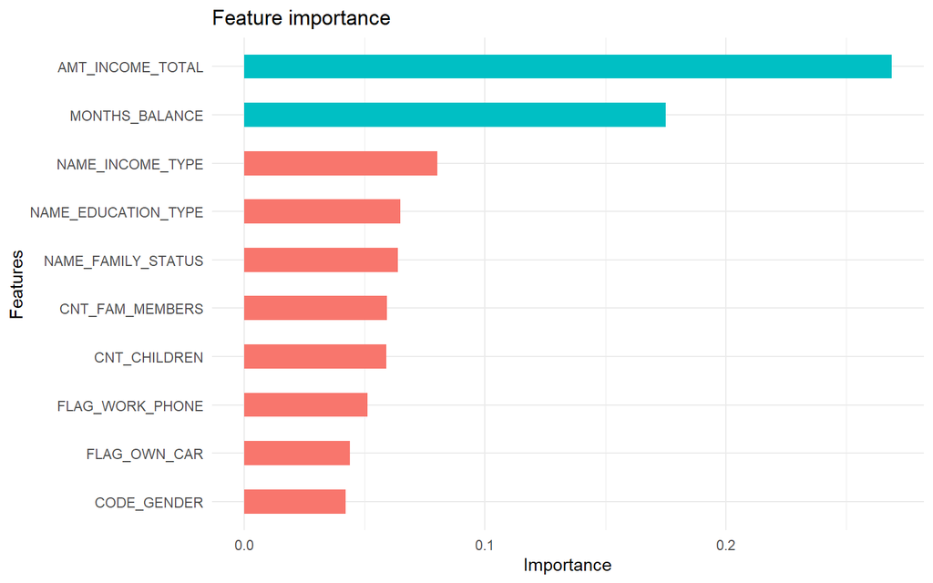

```r
var_imp <- xgb.importance(model = xgb1,
                          feature_names = dimnames(dtrain)[[2]])
xgb.ggplot.importance(var_imp,top_n = 10) +
  theme_minimal()+
  theme(legend.position = "none")
```

The graph above displays information about the 10 most influential variables in the model. Annual income and months balance are the two most important variables in this model.

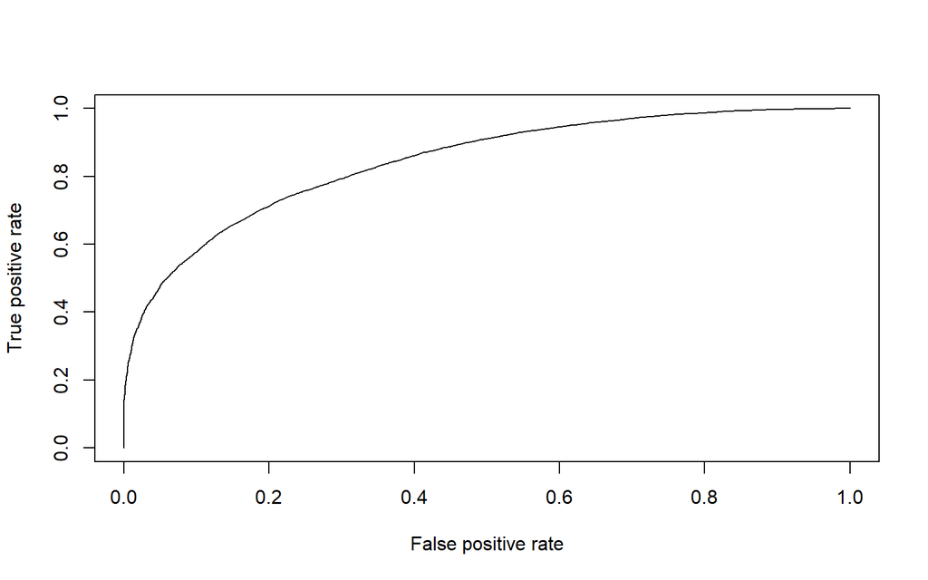

```r
xgb_result <- data.frame(class1 = xgbpred_prob, actual = as.factor(label_test))

auc_xgb <- roc_auc(data = xgb_result, truth = actual,class1)
value_roc_xgb <- prediction(predictions = xgbpred_prob,
                        labels = label_test)

# ROC curve
plot(performance(value_roc_xgb, "tpr", "fpr"))
```

```r
value_auc_xgb <- performance(value_roc_xgb, measure = "auc")
value_auc_xgb@y.values
```

```
#> [[1]]
#> [1] 0.8434915
```

The AUC value obtained in this model is 0.84, meaning that the model can predict well the two target classes namely `good credit` and `bad credit`. It is hoped that this model can be used by banks to determine credit scoring by entering customer profile data, then the results obtained can be visualized as follows:

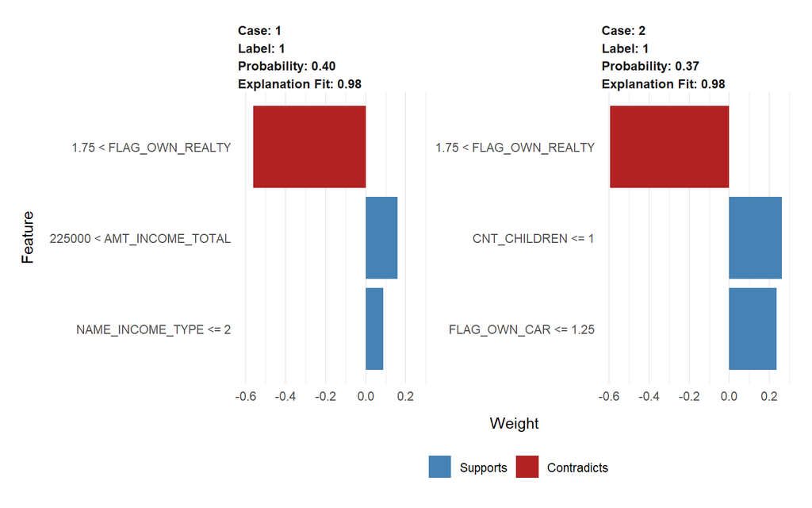

```r
explainer <- lime(train_matrix %>% as.data.frame(), xgb1)
explanation <- explain(test_matrix[11:12,] %>% as.data.frame(),
                             explainer,
                             labels = "1",
                             n_features = 3,
                             n_permutations = 5000,
                             dist_fun = "manhattan",
                             kernel_width = 0.75,
                             feature_select = "highest_weights")

plot_features(explanation)
```